# Uppföljning av indikatorerna i den regionala utvecklingsstrategin Västmanland

Utgiven

21 september 2026

## Sammanfattning

Denna rapport har tagits fram för att samla alla indikatorer i den regionala utvecklingsstrategin på ett överskådligt sätt. Det finns ett mer omfattande material publicerat via Region Västmanlands statistikrapporter, där det går att följa utvecklingen inom de olika mål- och insatsområdena mer i detalj och för länets kommuner. [Här hittar du uppföljningen.](https://app.powerbi.com/view?r=eyJrIjoiMGE1Mjk1MmQtMjZmMi00MGEwLWExMzAtN2ExMzYxMTRiZjM5IiwidCI6ImMyNzg4N2VkLTBmNGQtNGZmYS04OGFmLTIzOWNmOTg4NDE3OCIsImMiOjh9)

För att kunna sätta aktuell status för indikatorerna har vi renodlat värdena till att avse Västmanland totalt. För varje indikator jämförs det senaste mätvärdet med det föregående och statusen blir positiv om värdet har utvecklats positivt. Indikatorer som istället utvecklats negativt får således statusen negativ. Ett helt oförändrat värde räknas som positivt, däremot kan även en mycket liten ökning eller minskning slå igenom i sättandet av status, vilket kan vara värt att ha i åtanke.För indikatorer som anges i procent (till exempel sysselsättningsgrad) visas förändringen i procentenheter (pe). För övriga indikatorer, som visas i antal eller som index, visas förändringen i procent.

### Huvudindikatorer

Uppföljningen omfattar **29 huvudindikatorer** fördelade på tre målområden. **16 av 29** (55%) utvecklas positivt sedan föregående mätning.

### Samtliga indikatorer

Räknas samtliga indikatorer in, oavsett om de är huvudindikatorer eller inte, omfattar uppföljningen **65 indikatorer**. **40 av 65** (62%) utvecklas positivt sedan föregående mätning.

### Huvudindikatorer fördelade efter målområde

Inom **Ett välmående Västmanland** utvecklas 7 av 12 huvudindikatorer (58%) positivt sedan föregående mätning: bland annat Blomstrande hälsa, åk9 o gymn, Upplevd hälsa, samtliga åk och Gymnasieelever som uppnått grundläggande behörighet till universitet och högskola inom 4 år.

Inom **Ett tillgängligt Västmanland** utvecklas 5 av 10 huvudindikatorer (50%) positivt sedan föregående mätning: BUP första behandling inom 30 dagar, BUP första besök inom 30 dagar, Tillgänglighet till samhällsservice, Solceller: installerad effekt per capita, watt och Kollektivtrafikens marknadsandel.

Inom **Ett nyskapande Västmanland** utvecklas 4 av 7 huvudindikatorer (57%) positivt sedan föregående mätning: BRP, volymutveckling i procent, Andel som läst vidare inom 3 år, FoU-investeringar, samtliga sektorer och Nystartade företag, totalt.

| Målområde | Antal indikatorer | Positiva | Negativa | Andel positiva (%) |
| --- | --- | --- | --- | --- |
| Ett välmående Västmanland | 12 | 7 | 5 | 58 |
| Ett tillgängligt Västmanland | 10 | 5 | 5 | 50 |
| Ett nyskapande Västmanland | 7 | 4 | 3 | 57 |

## Samtliga indikatorer per insatsområde

### God och jämlik hälsa

Alla i Västmanland ska kunna trivas och må bra. Genom satsningar på hälsa, gemenskap och en rättvis arbetsmarknad skapas ett tryggt och inkluderande län där fler kan utvecklas. Här följer vi bland annat upp den självupplevda fysiska och psykiska hälsan och unga och vuxna. 3 av 7 indikatorer inom *God och jämlik hälsa* utvecklas positivt.

| Indikator | Senaste värde | Förändring | Status |
| --- | --- | --- | --- |
| **God psykisk hälsa bland unga i skolan (%)** | 49 | 9 pe | Positiv |
| **God hälsa, vuxna (%)** | 70 | -3 pe | Negativ |
| **God psykisk hälsa, vuxna (%)** | 85 | -0.7 pe | Negativ |
| **God hälsa bland unga i skolan (%)** | 73 | 8 pe | Positiv |
| Unga som är fysiskt aktiva (%) | 65 | 3 pe | Positiv |
| Ohälsotal (dagar) | 25 | 0.4% | Negativ |
| Tillgång till den hälso- och sjukvård man behöver (%) | 91 | -0.1 pe | Negativ |

Nedan visas utvecklingen i faktiska värden för indikatorerna inom insatsområdet. Där det är möjligt jämförs utvecklingen i Västmanland med riket.

**God psykisk hälsa bland unga i skolan (%)**

[interactive chart not shown]

**God hälsa, vuxna (%)**

[interactive chart not shown]

**God psykisk hälsa, vuxna (%)**

[interactive chart not shown]

**God hälsa bland unga i skolan (%)**

[interactive chart not shown]

**Unga som är fysiskt aktiva (%)**

[interactive chart not shown]

**Ohälsotal (dagar)**

[interactive chart not shown]

**Tillgång till den hälso- och sjukvård man behöver (%)**

[interactive chart not shown]

### Alla barn ska få en bra start i livet

För att alla barn i Västmanland ska få en god uppväxt krävs insatser som minskar skillnaderna i barns livsvillkor. Här följer vi till exempel upp andelen barn som lever i hushåll med låg ekonomisk standard och grundskoleresultat i länets kommuner. 7 av 7 indikatorer inom *Alla barn ska få en bra start i livet* utvecklas positivt.

| Indikator | Senaste värde | Förändring | Status |
| --- | --- | --- | --- |
| **Elever som uppnått betygskriterier åk 6 (%)** | 65 | 3 pe | Positiv |
| **Elever med gymnasiebehörighet åk 9 (%)** | 82 | 4 pe | Positiv |
| **Högskolebehörighet inom 4 år (%)** | 47 | 3 pe | Positiv |
| **Barn i hushåll med låg ekonomisk standard (%)** | 21 | 0 pe | Positiv |
| Idrottsdeltagande, barn (antal/invånare) | 32 | 10% | Positiv |
| Unga med föräldrar med låg utbildning (%) | 8 | -0.6 pe | Positiv |
| Unga med minst en långtidsarbetslös förälder (%) | 21 | -0.3 pe | Positiv |

Nedan visas utvecklingen i faktiska värden för indikatorerna inom insatsområdet. Där det är möjligt jämförs utvecklingen i Västmanland med riket.

**Elever som uppnått betygskriterier åk 6 (%)**

[interactive chart not shown]

**Elever med gymnasiebehörighet åk 9 (%)**

[interactive chart not shown]

**Högskolebehörighet inom 4 år (%)**

[interactive chart not shown]

**Barn i hushåll med låg ekonomisk standard (%)**

[interactive chart not shown]

**Idrottsdeltagande, barn (antal/invånare)**

[interactive chart not shown]

**Unga med föräldrar med låg utbildning (%)**

[interactive chart not shown]

**Unga med minst en långtidsarbetslös förälder (%)**

[interactive chart not shown]

### Ökad livskvalitet och förbättrade livsmiljöer

För att människor ska trivas och känna sig trygga i Västmanland behöver samhället fungera bra på flera sätt. Barn och vuxna ska känna sig trygga både hemma och ute i samhället. Skillnader i möjligheter till skola, arbete, fritid, svenska språket och mötesplatser får inte vara alltför stora mellan olika bostadsområden i länet. Vi följer bland annat upp den upplevda tryggheten hos unga och vuxna och hur segregationen och ojämlikheter utvecklas.  
2 av 6 indikatorer inom *Ökad livskvalitet och förbättrade livsmiljöer* utvecklas positivt.

| Indikator | Senaste värde | Förändring | Status |
| --- | --- | --- | --- |
| **Trygghet bland vuxna (%)** | 91 | -0.2 pe | Negativ |
| **Trygghet bland unga i skolan (%)** | 48 | -3 pe | Negativ |
| **Boende i områden med stora socioekonomiska skillnader (%)** | 9 | 0.2 pe | Negativ |
| **Ojämlikhetsindex** | 44 | -0.8% | Positiv |
| Bristande tillit hos vuxna (%) | 31 | 2 pe | Negativ |
| Barn i trångboddhet (%) | 31 | -2 pe | Positiv |

Nedan visas utvecklingen i faktiska värden för indikatorerna inom insatsområdet. Där det är möjligt jämförs utvecklingen i Västmanland med riket.

**Trygghet bland vuxna (%)**

[interactive chart not shown]

**Trygghet bland unga i skolan (%)**

[interactive chart not shown]

**Boende i områden med stora socioekonomiska skillnader (%)**

[interactive chart not shown]

**Ojämlikhetsindex**

[interactive chart not shown]

**Bristande tillit hos vuxna (%)**

[interactive chart not shown]

**Barn i trångboddhet (%)**

[interactive chart not shown]

### Ökad möjlighet att leva och verka i hela länet

En utbyggd och pålitlig kollektivtrafik gör det lättare att bo och arbeta i hela länet och underlättar pendling över länsgränserna. Samtidigt stärker tillgången till bra digital uppkoppling möjligheten till distansarbete, tillgång till tjänster och digital delaktighet. Vi följer bland annat upp befolkningens möjligheter till att få snabbt bredband och hur stor marknadsandel kollektivtrafiken har i länet. 5 av 6 indikatorer inom *Ökad möjlighet att leva och verka i hela länet* utvecklas positivt.

| Indikator | Senaste värde | Förändring | Status |
| --- | --- | --- | --- |
| **Möjlighet till snabbt bredband (%)** | 97 | -1 pe | Negativ |
| **Kollektivtrafikens marknadsandel (%)** | 14 | 0 pe | Positiv |
| Inpendling över länsgräns (%) | 33 | 1 pe | Positiv |
| Utpendling över länsgräns (%) | 43 | 0.9 pe | Positiv |
| Hanterat gods vid Mälarhamnarna (miljoner ton) | 2,6 | 4% | Positiv |
| Balans på bostadsmarknaden (antal kommuner) | 4 | 0% | Positiv |

Nedan visas utvecklingen i faktiska värden för indikatorerna inom insatsområdet. Där det är möjligt jämförs utvecklingen i Västmanland med riket.

**Möjlighet till snabbt bredband (%)**

[interactive chart not shown]

**Kollektivtrafikens marknadsandel (%)**

[interactive chart not shown]

**Inpendling över länsgräns (%)**

[interactive chart not shown]

**Utpendling över länsgräns (%)**

[interactive chart not shown]

**Hanterat gods vid Mälarhamnarna (miljoner ton)**

[interactive chart not shown]

**Balans på bostadsmarknaden (antal kommuner)**

[interactive chart not shown]

### God tillgång till samhällsservice, tjänster och utbud

Tillgången till hälso- och sjukvård är en nyckelfråga, arbetet med Nära vård ska skapa en mer tillgänglig och jämlik vård i länet. Viss grundläggande samhällsservice måste kunna nås och användas oavsett om du bor i staden eller på landsbygden.

Indikatorerna för tillgänglighet för sjukvården mäts uppdelat efter de olika aspekterna i vårdgarantin. Tillgänglighet till samhällsservice i länets kommuner mäter vi genom ett tillgänglighetsindex som Tillväxtverket har tagit fram. 5 av 9 indikatorer inom *God tillgång till samhällsservice, tjänster och utbud* utvecklas positivt.

| Indikator | Senaste värde | Förändring | Status |
| --- | --- | --- | --- |
| **BUP, behandling inom 30 dagar (%)** | 45 | 1 pe | Positiv |
| **BUP, första besök inom 30 dagar (%)** | 75 | 25 pe | Positiv |
| **Medicinsk bedömning inom tre dagar, primärvård (%)** | 79 | -3 pe | Negativ |
| **Specialiserad vård: förstabesök inom 90 dagar (%)** | 76 | -1 pe | Negativ |
| **Specialiserad vård: operation/åtgärd inom 90 dagar (%)** | 66 | -2 pe | Negativ |
| **Tillgänglighet till samhällsservice (index)** | 88 | 3% | Positiv |
| Elbilsladdpunkter (antal) | 1 383 | 23% | Positiv |
| Gästnätter (antal) | 974 150 | 7% | Positiv |
| Kulturbesökare (antal) | 176 716 | -9% | Negativ |

Nedan visas utvecklingen i faktiska värden för indikatorerna inom insatsområdet. Där det är möjligt jämförs utvecklingen i Västmanland med riket.

**BUP, behandling inom 30 dagar (%)**

[interactive chart not shown]

**BUP, första besök inom 30 dagar (%)**

[interactive chart not shown]

**Medicinsk bedömning inom tre dagar, primärvård (%)**

[interactive chart not shown]

**Specialiserad vård: förstabesök inom 90 dagar (%)**

[interactive chart not shown]

**Specialiserad vård: operation/åtgärd inom 90 dagar (%)**

[interactive chart not shown]

**Tillgänglighet till samhällsservice (index)**

[interactive chart not shown]

**Elbilsladdpunkter (antal)**

[interactive chart not shown]

**Gästnätter (antal)**

[interactive chart not shown]

**Kulturbesökare (antal)**

[interactive chart not shown]

### Säkerställda viktiga samhällsfunktioner

För att Västmanland ska stå starkt i både vardag och kris krävs robusta samhällsfunktioner, trygg energiförsörjning och ökad självförsörjning. Vi följer bland annat upp slutanvändningen av energi och kommunernas kostnader för totalförsvar och samhällsskydd. 7 av 10 indikatorer inom *Säkerställda viktiga samhällsfunktioner* utvecklas positivt.

| Indikator | Senaste värde | Förändring | Status |
| --- | --- | --- | --- |
| **Slutanvändning av energi (Mwh/inv)** | 30 | 2% | Negativ |
| **Solceller, installerad effekt (watt)** | 568 | 7% | Positiv |
| Avfallsförebyggande arbete (antal kommuner) | 8 | 60% | Positiv |
| Aktuell energiplan (antal kommuner) | 6 | -14% | Negativ |
| Klimatanpassningsplaner (antal kommuner) | 5 | 150% | Positiv |
| Biogasproduktion (Gwh) | 75 | 5% | Positiv |
| Produktionsdjur i jordbruket (antal) | 75 636 | 6% | Positiv |
| Jordbruksföretag (antal) | 1 364 | -0.9% | Negativ |
| Kostnad totalförsvar och samhällsskydd (kr/inv) | 133 | 24% | Positiv |
| Åkermark (ha) | 99 104 | 0.1% | Positiv |

Nedan visas utvecklingen i faktiska värden för indikatorerna inom insatsområdet. Där det är möjligt jämförs utvecklingen i Västmanland med riket.

**Slutanvändning av energi (Mwh/inv)**

[interactive chart not shown]

**Solceller, installerad effekt (watt)**

[interactive chart not shown]

**Kommunala planer**

[interactive chart not shown]

**Biogasproduktion (Gwh)**

[interactive chart not shown]

**Jordbruk: index (basår = 100)**

[interactive chart not shown]

**Kostnad totalförsvar och samhällsskydd (kr/inv)**

[interactive chart not shown]

### Stärkt näringsliv, konkurrenskraft och produktivitet

För att stärka Västmanlands näringsliv behövs satsningar på teknisk industri, gröna näringar och tjänstesektorn, samt entreprenörskap och nyföretagande. Vi följer bland annat upp den ekonomiska utvecklingen i form av bruttoregionproduktens utveckling och hur sysselsättningen utvecklas. 4 av 8 indikatorer inom *Stärkt näringsliv, konkurrenskraft och produktivitet* utvecklas positivt.

| Indikator | Senaste värde | Förändring | Status |
| --- | --- | --- | --- |
| **BRP:s volymutveckling (%)** | -0,3 | 4 pe | Positiv |
| **Sysselsättningsgrad (%)** | 80 | -0.7 pe | Negativ |
| **Sysselsatt dagbefolkning (antal)** | 128 648 | -0.3% | Negativ |
| Exportföretag (antal) | 585 | 4% | Positiv |
| Förädlingsvärde, miljösektorn (Mnkr) | 5 905 | -5% | Negativ |
| Näringslivsklimat, sammanvägt index | 68 | 2% | Positiv |
| Sysselsatta inom miljösektorn (antal) | 4 099 | 2% | Positiv |
| Sysselsatt nattbefolkning (antal) | 134 539 | -0.8% | Negativ |

Nedan visas utvecklingen i faktiska värden för indikatorerna inom insatsområdet. Där det är möjligt jämförs utvecklingen i Västmanland med riket.

**BRP:s volymutveckling (%)**

[interactive chart not shown]

**Sysselsättningsgrad (%)**

[interactive chart not shown]

**Sysselsatt dagbefolkning (antal)**

[interactive chart not shown]

**Exportföretag (antal)**

[interactive chart not shown]

**Förädlingsvärde, miljösektorn (Mnkr)**

[interactive chart not shown]

**Näringslivsklimat, sammanvägt index**

[interactive chart not shown]

**Sysselsatta inom miljösektorn (antal)**

[interactive chart not shown]

**Sysselsatt nattbefolkning (antal)**

[interactive chart not shown]

### Ökad forskning, innovation och förnyelse

Västmanland har en stark position inom innovation. För att ytterligare förstärka positionen krävs satsningar som stärker nyföretagande, forskning och teknikutveckling. Här följer vi till exempel upp nyföretagandet i länet och investeringar i forskning och utveckling. 4 av 6 indikatorer inom *Ökad forskning, innovation och förnyelse* utvecklas positivt.

| Indikator | Senaste värde | Förändring | Status |
| --- | --- | --- | --- |
| **FoU-investeringar (Mnkr)** | 3 737 | 28% | Positiv |
| **Nyföretagande (antal)** | 1 757 | 16% | Positiv |
| Designansökningar (antal) | 4 | -50% | Negativ |
| Patentansökningar (antal) | 23 | 10% | Positiv |
| Små och medelstora företag med innovationsförmåga (%) | 33 | -9 pe | Negativ |
| Sysselsatta inom kunskapsintensiva yrken (%) | 42 | 0.8 pe | Positiv |

Nedan visas utvecklingen i faktiska värden för indikatorerna inom insatsområdet. Där det är möjligt jämförs utvecklingen i Västmanland med riket.

**FoU-investeringar (Mnkr)**

[interactive chart not shown]

**Nyföretagande (antal)**

[interactive chart not shown]

**Patent och design**

[interactive chart not shown]

**Små och medelstora företag med innovationsförmåga (%)**

[interactive chart not shown]

**Sysselsatta inom kunskapsintensiva yrken (%)**

[interactive chart not shown]

### Tryggad kompetensförsörjning och möjlighet till livslångt lärande

För att Västmanland ska klara framtidens kompetensbehov måste fler utbilda sig och fler få jobb. Vi följer upp såväl arbetslöshetens utveckling som hur stor andel av länets gymnasieexaminerade som går vidare till högre studier. 3 av 6 indikatorer inom *Tryggad kompetensförsörjning och möjlighet till livslångt lärande* utvecklas positivt.

| Indikator | Senaste värde | Förändring | Status |
| --- | --- | --- | --- |
| **Andel som läst vidare inom tre år (%)** | 48 | 2 pe | Positiv |
| **Arbetslöshet 20-64 år (%)** | 7 | 0.7 pe | Negativ |
| Andel med eftergymnasial utbildning (%) | 35 | 3 pe | Positiv |
| UVAS 16-24 år (%) | 7 | 0.6 pe | Negativ |
| UVAS 25-29 år (%) | 12 | 0.8 pe | Negativ |
| Matchningsgrad mellan utbildning och yrke (%) | 72 | 0.1 pe | Positiv |

Nedan visas utvecklingen i faktiska värden för indikatorerna inom insatsområdet. Där det är möjligt jämförs utvecklingen i Västmanland med riket.

**Andel som läst vidare inom tre år (%)**

[interactive chart not shown]

**Arbetslöshet 20-64 år (%)**

[interactive chart not shown]

**Andel med eftergymnasial utbildning (%)**

[interactive chart not shown]

**UVAS 16-24 år (%)**

[interactive chart not shown]

**UVAS 25-29 år (%)**

[interactive chart not shown]

**Matchningsgrad mellan utbildning och yrke (%)**

[interactive chart not shown]

## Riksjämförelse – huvudindikatorer

Diagrammet visar hur Västmanlands huvudindikatorer förhåller sig till riket i två dimensioner: **x-axeln** visar nivån relativt riket och **y-axeln** hur indikatorns utveckling har sett ut. Värden är justerade så att positiv riktning alltid är det önskvärda i figuren, oavsett om indikatorn ska öka eller minska. Ett exempel är arbetslösheten där en miskning naturligtvis är bättre än en ökning. Anpassningen har gjorts så att alla indikatorer i figuren ska kunna läsas på samma sätt. Nivån för Västmanland relativt riket är beräknat som Västmanlands senaste värde minus riksvärdet, uttryckt som procent av riksvärdet. Det gör indikatorerna jämförbara oavsett vilken skala de använder i grunden. Observera också att diagrammet endast visar de huvudindikatorer som det är möjligt att jämföra med riket.

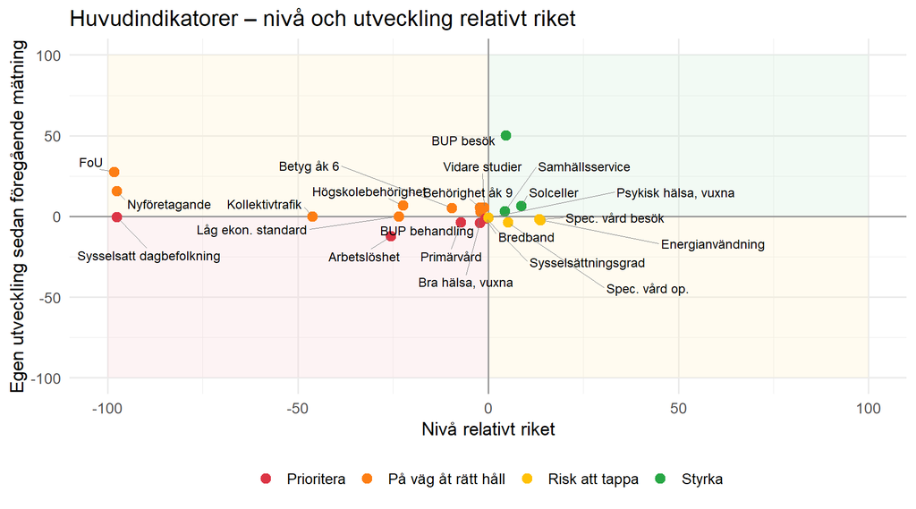

**Styrka** – god nivå relativt riket och positiv utveckling - BUP, första besök inom 30 dagar (%) - Solceller, installerad effekt (watt) - Tillgänglighet till samhällsservice (index)

**På väg åt rätt håll** – svagare nivå men positiv utveckling - Andel som läst vidare inom tre år (%) - Barn i hushåll med låg ekonomisk standard (%) - BUP, behandling inom 30 dagar (%) - Elever med gymnasiebehörighet åk 9 (%) - Elever som uppnått betygskriterier åk 6 (%) - FoU-investeringar (Mnkr) - Högskolebehörighet inom 4 år (%) - Kollektivtrafikens marknadsandel (%) - Nyföretagande (antal)

**Risk att tappa** – god nivå men negativ utveckling - God psykisk hälsa, vuxna (%) - Slutanvändning av energi (Mwh/inv) - Specialiserad vård: förstabesök inom 90 dagar (%) - Specialiserad vård: operation/åtgärd inom 90 dagar (%)

**Prioritera** – svagare nivå och negativ utveckling - Arbetslöshet 20-64 år (%) - God hälsa, vuxna (%) - Medicinsk bedömning inom tre dagar, primärvård (%) - Möjlighet till snabbt bredband (%) - Sysselsatt dagbefolkning (antal) - Sysselsättningsgrad (%)

## Om indikatorerna

Nedan finns mer utförlig information om vad de olika indikatorerna mäter och varifrån uppgifterna är hämtade.

### God och jämlik hälsa

| Indikator | Mäter | Källa |
| --- | --- | --- |
| Upplevd hälsa bland barn och vuxna | Andel som svarat på bra eller mycket bra på frågan “Hur mår du rent allmänt?” (barn och unga) respektive “Hur bedömer du ditt allmänna hälsotillstånd?” (vuxna). | Liv och hälsa; Hälsa på lika villkor (FHM) |
| Befolkningens psykiska välbefinnande | Barn och unga: Psykisk hälsa mättes med Keyes Mental Health Continuum – Short Form (MHCSF). Den innehåller 14 tecken på psykiskt välbefinnande och speglar samtliga tre delar av WHO:s definition av psy… | \|Hälsa på lika villkor (FHM) |
| Invånare som är fysiskt aktiva | Invånare 16-84 år som är fysiskt aktiva minst 150 min/vecka | Liv och hälsa; Hälsa på lika villkor (FHM) |
| Ohälsotalet | Ohälsotalet är ett mått på utbetalda dagar med sjukpenning, arbetsskadesjukpenning, rehabiliteringspenning, aktivitets- och sjukersättning från socialförsäkringen. Ohälsotalet beräknas genom att summa… | Försäkringskassan |
| Självupplevd tillgång till hälso- och sjukvård | Andel som instämmer helt eller delvis i påståendet “Jag har tillgång till den hälso- och sjukvård jag behöver”. | Hälso- och sjukvårdsbarometern. Vården i siffror. |

### Alla barn ska få en bra start i livet

| Indikator | Mäter | Källa |
| --- | --- | --- |
| Barn i hushåll med låg inkomststandard | Andel invånare 0-19 år med låg ekonomisk standard uttryckt i %. Disponibel inkomst är summan av alla skattepliktiga och skattefria inkomster minus skatt och övriga negativa transfereringar. Inkomsten … | Statistiska centralbyrån |
| Resultat i grundskolan och gymnasiet | Andel elever i åk 6 som uppnått betygskriterierna i alla ämnen (hemkommun); Andel elever i åk 9 som uppnått betygskriterierna i alla ämnen (hemkommun); Elever i åk 9 som är behöriga till yrkesprogram … | Skolverket och Statistiska centralbyrån |
| Barn och unga med föräldrar som har högst grundskoleutbildning | Antal invånare 0-19 år med föräldrar som har högst grundskoleutbildning dividerat med totalt antal invånare 0-19 år, multiplicerat med 100. Avser 31/12. Källa: SCB. | Statistiska centralbyrån |
| Barn och unga med minst en långtidsarbetslös förälder | Antal invånare 0-19 med minst en långtidsarbetslös förälder dividerat med totalt antal invånare 0-19 år, multiplicerat med 100. Med långtidsarbetslöshet avses helt utan arbete eller i arbetsmarknadspo… | Statistiska centralbyrån |
| Barn som deltar i idrottsförening | Deltagartillfällen i idrottsföreningar, antal/invånare 7-12 år | Riksidrottsförbundet |

### Ökad livskvalitet och förbättrade livsmiljöer

| Indikator | Mäter | Källa |
| --- | --- | --- |
| Upplevd trygghet hos barn och vuxna | Andel elever som svarat “alltid” på frågan om de känner sig trygga i skolan; Andel vuxna som svarat stämmer ganska eller mycket väl för påståendet “I det här området kan man känna sig säker och trygg … | Liv och hälsa; Hälsa på lika villkor (FHM) |
| Segregation | Utveckling av ojämlikhetsindex och områden med socioekonomiska utmaningar, befolkningens fördelning efter de olika områdestyperna. Ojämlikhetsindexet är ett mått på skillnaden i bosättningsmönster mel… | Statistiska centralbyrån, Boverket (tidigare Delmos). |
| Trångboddhet | Antal trångbodda personer i flerbostadshus enligt norm 2. Trångbodd enligt norm 2: Norm två infördes på 1960-talet och definieras som högst två personer per rum och dessutom ska det finnas ett kök och… | Statistiska centralbyrån |
| Invånare med låg tillit till andra | Andel som svarat nej på frågan “Tycker du att man i allmänhet kan lita på de flesta människor”. | Liv och hälsa; Hälsa på lika villkor (FHM) |
| Medborgarengagemang och demokratisk delaktighet | Medborgarengagemang och demokratisk delaktighet baseras på indikatorerna Valdeltagande i senaste kommunalvalet, andel (%), Valdistrikt med lägst valdeltagande i senaste kommunalval, andel (%), Kvinnor… | Tillväxtverkets beräkningar, baserade på uppgifter från Folkhälsomyndigheten, SCB, Skolinspektionen, Riksidrottsförbundet, Valmyndigheten |

### Ökad möjlighet att leva och verka i hela länet

| Indikator | Mäter | Källa |
| --- | --- | --- |
| Tillgång till snabbt bredband | Andel hushåll och arbetsställen som har tillgång till fast bredband om minst 1 Gbit/s, eller fiber i absoluta närheten. | Post- och telestyrelsen |
| Kollektivtrafikens marknadsandel | Andel kollektivtrafikresor av samtliga resor med motorburen trafik - för respektive bolag som tillhandahåller kollektivtrafik i respektive län/region. | Kollektivtrafikbarometern |
| Bostadsmarknad och byggande | Antal nyproducerade lägenheter; Bostadsbestånd; Kommunernas bedömning av läget på bostadsmarknaden | SCB, Boverket/Länsstyrelsen. |
| Pendling, över länsgräns och inom länet | In- och utpendling över läns- och kommungräns | Statistiska centralbyrån |
| Hanterat gods vid Mälarhamnarna | Hanterat gods vid Mälarhamnar, miljoner ton | Mälarhamnar, Transportföretagen |

### God tillgång till samhällsservice, tjänster och utbud

| Indikator | Mäter | Källa |
| --- | --- | --- |
| Tillgänglighet till hälso- och sjukvården | Andel som fått: Medicinsk bedömning inom tre dagar, primärvård; Planerad specialiserad vård: förstabesök inom 90 dagar; Planerad specialiserad vård: operation/åtgärd inom 90 dagar; Särskild satsning B… | SKR, Väntetider i vården |
| Tillgänglighet till samhällsservice | Totalt tillgänglighetsindex (samtliga färdsätt). Beräkning enligt Beteendemodellen i Pipos Regionalanalys. | Tillväxtverket, Pipos serviceanalys |
| Deltagande i kultur- och fritidsaktiviteter | Antal besökare vid kulturaktiviteter; Andel skolungdomar i Västmanlands län som regelbundet deltar i fritidsaktiviteter med ledare | Kulturanalys, Liv och hälsa ung |
| Laddplatser för elbilar | Antal elbilsladdpunkter, totalt och efter typ av laddare | Energimyndigheten, Nobil |
| Besöksnäringens utveckling (gästnätter, sysselsättning, ekonomiskt värde) | Antal gästnätter (januari-december) efter ursprungsland | Tillväxtverket |

### Säkerställda viktiga samhällsfunktioner

| Indikator | Mäter | Källa |
| --- | --- | --- |
| Utveckling av solcellsanläggningar och biogasproduktion | Installerad effekt i MW totalt och watt per capita för solcellsanläggningar. Biogasproduktion i GWh. | Energimyndigheten |
| Slutanvändning av energi inom länet | Slutanvändning av energi totalt inom det geografiska området, MWh/inv. Avser total slutanvändning av energi som sker inom det geografiska områdets gränser. För att SCB ska kunna publicera uppgifter kr… | Energimyndigheten och SCB |
| Utveckling av åker- och betesmark, jordbruksföretag och djurhållning | Hektar åker- och betesmark, antal jordbruksföretag, antal djur (nöt, gris, får) | Jordbruksverket |
| Beredskap för klimat, energi och avfall | Antal kommuner i länet som svarat att det finns aktuella dokument för anpassning till ett förändrat klimat, t.ex. ökade översvämningsrisker, ras- och skredrisker och extremt väder; kommunal energiplan… | Boverket, Miljömålsenkäten |
| Kostnad för totalförsvar och samhällsskydd | Nettokostnad för totalförsvar och samhällsskydd dividerat med antal invånare. Med nettokostnad avses bruttokostnad minus bruttointäkt. Avser administration av civilförsvarsfrågor. Utarbetande av plane… | SCB:s Räkenskapssammandrag |

### Stärkt näringsliv, konkurrenskraft och produktivitet

| Indikator | Mäter | Källa |
| --- | --- | --- |
| Sysselsättning | Antal sysselsatta (med bostad respektive arbetsplats i länet). Förvärvsgrad 20-65 år (andel sysselsatta av befolkningen). | Statistiska centralbyrån |
| Ekonomisk utveckling | Bruttoregionprodukt, volymutveckling i procent; BRP löpande och i fast pris | Statistiska centralbyrån |
| Exporterande företag | Antal varuexporterande företag per storleksklass efter säteslän. Ekonomiska värden är däremot beräknade med utgångspunkt i arbetsställets belägenhet i syfte att bättre förstå var de ekonomska värdena … | Statistiska centralbyrån, STATIV |
| Företagsklimat | Sammanvägt index av två undersökningar av företagsklimat. 1) Svenskt näringslivs undersökning; Nöjd Kund Index, Företagsklimat 2) SKR:s undersökning Insikt, företagarnas helhetsbedömning av servicen i… | Svenskt Näringsliv, SKR |
| Miljösektorns utveckling | Antal sysselsatta inom miljösektorn, sektorns förädlingsvärde. SCB följer definitionen av miljösektorn som utarbetats inom Eurostat och EU. I EU-förordningen 691/2011 beskrivs sektorn för miljövänliga… | Statistiska centralbyrån |

### Ökad forskning, innovation och förnyelse

| Indikator | Mäter | Källa |
| --- | --- | --- |
| Nyföretagande | Antal nya företag per år. Statistiken över nystartade företag baseras på bearbetningar av företagsregistret vid Statistiska centralbyrån (SCB) enligt den metod som används i den EU-reglerade undersökn… | Tillväxtanalys |
| Investeringar i FoU | Totala utgifter för egen FoU-verksamhet efter sektor, Mnkr. Den offentliga sektorn innehåller förutom statliga myndigheter, regioner och kommuner även lokala och regionala FoU-enheter samt offentliga … | Statistiska centralbyrån |
| Sysselsatta inom kunskapsintensiva yrken | Antal och andel sysselsatta inom kunskapsintensiva yrken (nivå 1-3 i SSYK). | Statistiska centralbyrån |
| Ansökningar om patent i länet | Antal patentansökningar per år. | Patent- och registreringsverket |
| Små och medelstora företag med innovationsförmåga (produktutveckling) | Andel små och medelstora företag som har utvecklat och sålt nya eller väsentligt förbättrade varor och tjänster under de tre senaste åren | Tillväxtverket, Företagens villkor och verklighet |

### Tryggad kompetensförsörjning och möjlighet till livslångt lärande

| Indikator | Mäter | Källa |
| --- | --- | --- |
| Arbetslöshet | Antal invånare 20-64 år med status arbetslösa, dividerat med antal i arbetskraften 20-64 år. | Statistiska centyralbyrån, BAS |
| Övergång till högre studier | Examinerade från gymnasieskolan som påbörjat högskolestudier inom 1,3 eller 5 år. Efter typ av gymnasieprogram | Statistiska centralbyrån |
| Unga vuxna som varken arbetar eller studerar | Personer 16-24 år och 16-29 år som under kalenderåret inte haft inkomster som överskridit ett basbelopp, inte haft studiemedel, varit utbildningsregistrerad eller studerat vid SFI mer än 60 timmar. In… | Myndigheten för ungdoms- och civilsamhällesfrågor (mucf) |
| Andel anställda med matchning mellan utbildning och yrke | Andel anställda med matchning mellan utbildning och yrke (nattbefolkning). Matchningsgrad visar andelen anställda som arbetar i yrken som stämmer väl överens med deras utbildning. För att detta ska gä… | Statistiska centralbyrån |
| Andel med eftergymnasial utbildning | Invånare med eftergymnasial utbildning 25-64 år, andel (%). Eftergymnasial avser: eftergymnasial utbildning kortare än 3 år, längre än 3 år samt forskarutbildning. | Statistiska centralbyrån |